# Script 6: Checking GOTO genotypes

Compiled: June 25, 2024

> This script compares measured GOTO genotypes to those predicted from DNAm data to check for sample mixups.

# Setup

Load packages

```r
library(tidyverse)
library(snpStats)
```

Read in the GOTO genotyping files

```r
lls_plink <- read.plink(
  bed = '../GOTO_Data/Processing/Genotypes/GOTO.bed',
  bim = '../GOTO_Data/Processing/Genotypes/GOTO.bim',
  fam = '../GOTO_Data/Processing/Genotypes/GOTO.fam')
```

# OmicsPrint

Read in the results from omicsPrint (genotyping from DNA methylation values in each of the 3 tissues):

**1230 SNPs from 200 fasted blood samples**

```r
load('../GOTO_Data/Processing/omicsPrint/GOTO_omicsPrint-blood.Rdata')
dnam_blood <- as.data.frame(genotype)
rm(list = c('mismatches', 'out', 'relations', 'genotype'))
dim(dnam_blood)
```

```
## [1] 1230  200
```

**1010 SNPs from 164 muscle samples**

```r
load('../GOTO_Data/Processing/omicsPrint/GOTO_omicsPrint-muscle.Rdata')
dnam_muscle <- as.data.frame(genotype)
rm(list = c('mismatches', 'out', 'relations', 'genotype'))
dim(dnam_muscle)
```

```
## [1] 1010  164
```

```r
load('../GOTO_Data/Processing/omicsPrint/GOTO_omicsPrint-fat.Rdata')
dnam_fat <- as.data.frame(genotype)
rm(list = c('mismatches', 'out', 'relations', 'genotype'))
dim(dnam_fat)
```

```
## [1] 1059  184
```

# Key file

Read in key file sent from M.B.

```r
key_id_gwas <- read_csv('../GOTO_Data/Processing/Genotypes/GOTO_Labnrs-EDTA_20210222.csv')
key_id_gwas <- key_id_gwas %>% dplyr::select(IOP2_ID, labnr) %>% mutate(labnr = as.character(key_id_gwas$labnr))
```

Read in the targets file of the methylation data to link sample IDs to other IDs

```r
load('../GOTO_Data/Processing/GOTO_targets-unfiltered.Rdata')
key_id_dnam <- targets
rm('targets')
```

Save a sample ID key for each set of samples

**200 blood samples**

```r
key_blood <- key_id_dnam %>% dplyr::select(sample_ID = Basename,
                                      IOP2_ID,
                                      HMU_ID,
                                      DNA_labnr) %>%
  filter(sample_ID %in% colnames(dnam_blood)) %>%
  mutate(IOP2_ID = as.numeric(as.character(IOP2_ID)))

key_blood <- left_join(key_blood, key_id_gwas, by = 'IOP2_ID')
```

**164 muscle samples**

```r
key_muscle <- key_id_dnam %>% dplyr::select(sample_ID = Basename,
                                      IOP2_ID,
                                      HMU_ID,
                                      DNA_labnr) %>%
  filter(sample_ID %in% colnames(dnam_muscle)) %>%
  mutate(IOP2_ID = as.numeric(as.character(IOP2_ID)))


key_muscle <- left_join(key_muscle, key_id_gwas, by = 'IOP2_ID')
```

**184 fat samples**

```r
key_fat <- key_id_dnam %>% dplyr::select(sample_ID = Basename,
                                      IOP2_ID,
                                      HMU_ID,
                                      DNA_labnr) %>%
  filter(sample_ID %in% colnames(dnam_fat)) %>%
  mutate(IOP2_ID = as.numeric(as.character(IOP2_ID)))


key_fat <- left_join(key_fat, key_id_gwas, by = 'IOP2_ID')
```

Save

```r
save(key_blood, key_muscle, key_fat, file = '../GOTO_Data/Processing/Genotypes/GOTO_keys-48.Rdata')

rm(list = c('key_id_gwas', 'key_id_dnam'))
```

# Subsetting

## Annotating CpGs to SNPs

Load in mapping file from Zhou - 667132 CpGs

```r
cpg_snp <- read_tsv('../../../LLS/Shared_Data/Manifests/EPIC.hg38.commonsnp.tsv')
cpg_snp <- cpg_snp %>% dplyr::select(cpg=probeID, snpID)
```

Subset only CpGs that map to a single SNP

```r
cpg_snp <- cpg_snp %>% group_by(cpg) %>%
  mutate(n = n()) %>% ungroup() %>%
  filter(n == 1) %>% dplyr::select(-n)
```

Merge with the `beta2genotype` data

```r
dnam_blood <- dnam_blood %>% rownames_to_column(var = 'cpg')
dnam_blood <- inner_join(cpg_snp, dnam_blood, by = 'cpg')
```

```r
dnam_muscle <- dnam_muscle %>% rownames_to_column(var = 'cpg')
dnam_muscle <- inner_join(cpg_snp, dnam_muscle, by = 'cpg')
```

```r
dnam_fat <- dnam_fat %>% rownames_to_column(var = 'cpg')
dnam_fat <- inner_join(cpg_snp, dnam_fat, by = 'cpg')
```

## Keep only samples with genotype data

48 individuals were not part of LLS but participated in GOTO. These individuals are the ones kept here in the `beta2genotype` data.

The rownames of the genotype data must be converted to labnr

```r
rownames(lls_plink$genotypes) <- lls_plink$fam$member
```

First we subset the keys:

**46 / 200 blood samples have genotypes in GOTO data**

```r
key_blood <- key_blood %>% filter(labnr %in% (rownames(lls_plink$genotypes)))
dim(key_blood)
```

```
## [1] 46  5
```

**30 / 164 muscle samples have genotypes in GOTO data**

```r
key_muscle <- key_muscle %>% filter(labnr %in% (rownames(lls_plink$genotypes)))
dim(key_muscle)
```

```
## [1] 30  5
```

**44 / 184 fat samples have genotypes in GOTO data**

```r
key_fat <- key_fat %>% filter(labnr %in% (rownames(lls_plink$genotypes)))
dim(key_fat)
```

```
## [1] 44  5
```

Now we can subset the `beta2genotype` data using these keys

```r
dnam_blood <- dnam_blood %>% dplyr::select(cpg, snpID, key_blood$sample_ID)
dim(dnam_blood)
```

```
## [1] 595  48
```

```r
dnam_muscle <- dnam_muscle %>% dplyr::select(cpg, snpID, key_muscle$sample_ID)
dim(dnam_muscle)
```

```
## [1] 488  32
```

```r
dnam_fat <- dnam_fat %>% dplyr::select(cpg, snpID, key_fat$sample_ID)
dim(dnam_fat)
```

```
## [1] 508  46
```

## Subsetting the genotype data

Now we can use the finalized `beta2genotype` data to subset the genotype data, which contains data on 719665 SNPs from 48 individuals.

```r
lls_plink <- as.data.frame(t(lls_plink$genotypes))
dim(lls_plink)
```

```
## [1] 719665     48
```

```r
genotype_blood <- lls_plink %>% dplyr::select(key_blood$labnr) %>%
  rownames_to_column(var = 'snpID') %>%
  filter(snpID %in% dnam_blood$snpID) %>% arrange(snpID)
dim(genotype_blood)
```

```
## [1] 130  24
```

```r
genotype_muscle <- lls_plink %>% dplyr::select(key_muscle$labnr) %>%
  rownames_to_column(var = 'snpID') %>%
  filter(snpID %in% dnam_muscle$snpID) %>% arrange(snpID)
dim(genotype_muscle)
```

```
## [1] 100  16
```

```r
genotype_fat <- lls_plink %>% dplyr::select(key_fat$labnr) %>%
  rownames_to_column(var = 'snpID') %>%
  filter(snpID %in% dnam_fat$snpID) %>% arrange(snpID)
dim(genotype_fat)
```

```
## [1] 108  23
```

## Subsetting `beta2genotype` for SNPs

Finally we keep only the SNPs that overlap with genotype data

```r
dnam_blood <- dnam_blood %>% filter(snpID %in% genotype_blood$snpID) %>% arrange(snpID)
dim(dnam_blood)
```

```
## [1] 130  48
```

```r
dnam_muscle <- dnam_muscle %>% filter(snpID %in% genotype_muscle$snpID) %>% arrange(snpID)
dim(dnam_muscle)
```

```
## [1] 100  32
```

```r
dnam_fat <- dnam_fat %>% filter(snpID %in% genotype_fat$snpID) %>% arrange(snpID)
dim(dnam_fat)
```

```
## [1] 108  46
```

# Preprocessing

The genotype data needs to be converted to numeric

```r
genotype_blood[, c(2:ncol(genotype_blood))] <- sapply(genotype_blood[, c(2:ncol(genotype_blood))], as.numeric)

genotype_muscle[, c(2:ncol(genotype_muscle))] <- sapply(genotype_muscle[, c(2:ncol(genotype_muscle))], as.numeric)

genotype_fat[, c(2:ncol(genotype_fat))] <- sapply(genotype_fat[, c(2:ncol(genotype_fat))], as.numeric)
```

# Analysis

## Blood

Create a data frame of assumed and actual matches for each sample

```r
dnam <- dnam_blood
gwas <- genotype_blood
key <- key_blood

out_blood <- data.frame()

for(j in 3:ncol(dnam)){
  ind <- dnam[,j]
for(i in 2:ncol(gwas)){
  out_blood <- rbind(out_blood,
      data.frame(sample_ID = (colnames(dnam)[j]),
    actual_match = colnames(gwas)[i],
    assumed_match = key[key$sample_ID == colnames(dnam)[j],'labnr'],
    n_snps = data.frame(xtabs(~gwas[,i] == ind))[2,2]))
}
}

out <- out_blood %>% group_by(sample_ID) %>% mutate(max = max(n_snps)) %>% ungroup()
```

We visualize the results. For every sample the assumed match also has the most matching SNPs, suggesting no sample mixups for blood.

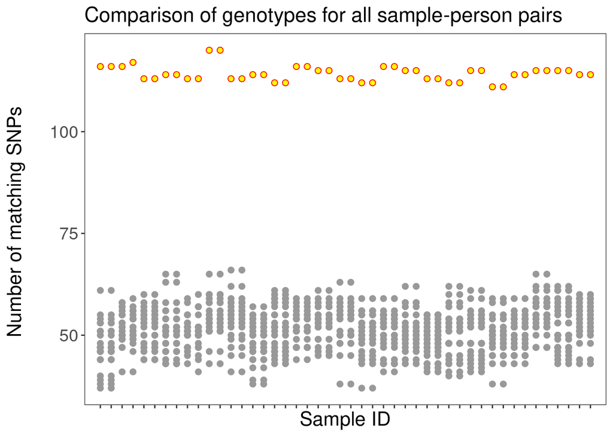

```r
out %>% ggplot(aes(x = sample_ID, y = n_snps)) +
  geom_point(fill = ifelse(out$actual_match == out$assumed_match,
                           'yellow', 'grey60'),
             color = ifelse(out$n_snps == out$max,
                            'red', 'grey60'),
             shape = 21, size = 2) +
  theme_bw() +
  ylab('Number of matching SNPs \n') + xlab('Sample ID') +
  ggtitle('Comparison of genotypes for all sample-person pairs') +
  theme(axis.text.x = element_text(angle = 90),
        panel.background = element_rect(fill = 'white'),
        axis.text.x.bottom = element_blank(),
        panel.grid = element_blank(),
        axis.title = element_text(size = 16),
        title = element_text(size = 14),
        axis.text.y = element_text(size = 14)) +
  scale_x_discrete(expand = c(-1.01,-1.01))
```

The smallest overlap is 111 SNPs and as shown above, no sample does not have the highest match with the assumed genotype

```r
out %>% filter(n_snps == max) %>% arrange(max)
```

```
## # A tibble: 46 × 5
##    sample_ID           actual_match assumed_match n_snps   max
##    <chr>               <chr>        <chr>          <int> <int>
##  1 203548980012_R03C01 2185         2185             111   111
##  2 203548980012_R04C01 2185         2185             111   111
##  3 203548970015_R05C01 2261         2261             112   112
##  4 203548970015_R06C01 2261         2261             112   112
##  5 203548870105_R03C01 2272         2272             112   112
##  6 203548870105_R04C01 2272         2272             112   112
##  7 203548970098_R03C01 2266         2266             112   112
##  8 203548970098_R04C01 2266         2266             112   112
##  9 203548870020_R01C01 2191         2191             113   113
## 10 203548870020_R02C01 2191         2191             113   113
## # ℹ 36 more rows
```

```r
out %>% filter(n_snps == max) %>% filter(actual_match != assumed_match)
```

```
## # A tibble: 0 × 5
## # ℹ 5 variables: sample_ID <chr>, actual_match <chr>, assumed_match <chr>,
## #   n_snps <int>, max <int>
```

Save

```r
save(out, key_blood, file='../GOTO_Data/Processing/Genotypes/GOTO_genotypeCheck-GOTO-blood.Rdata')
```

## Muscle

Create a data frame of assumed and actual matches for each sample

```r
dnam <- dnam_muscle
gwas <- genotype_muscle
key <- key_muscle

out_muscle <- data.frame()

for(j in 3:ncol(dnam)){
  ind <- dnam[,j]
for(i in 2:ncol(gwas)){
  out_muscle <- rbind(out_muscle,
  data.frame(sample_ID = (colnames(dnam)[j]),
  actual_match = colnames(gwas)[i],
  assumed_match = key[key$sample_ID == colnames(dnam)[j],'labnr'],
  n_snps = data.frame(xtabs(~gwas[,i] == ind))[2,2]))
}
}

out <- out_muscle %>% group_by(sample_ID) %>% mutate(max = max(n_snps)) %>% ungroup()
```

We visualize the results. For every sample the assumed match also has the most matching SNPs, suggesting no sample mixups for muscle.

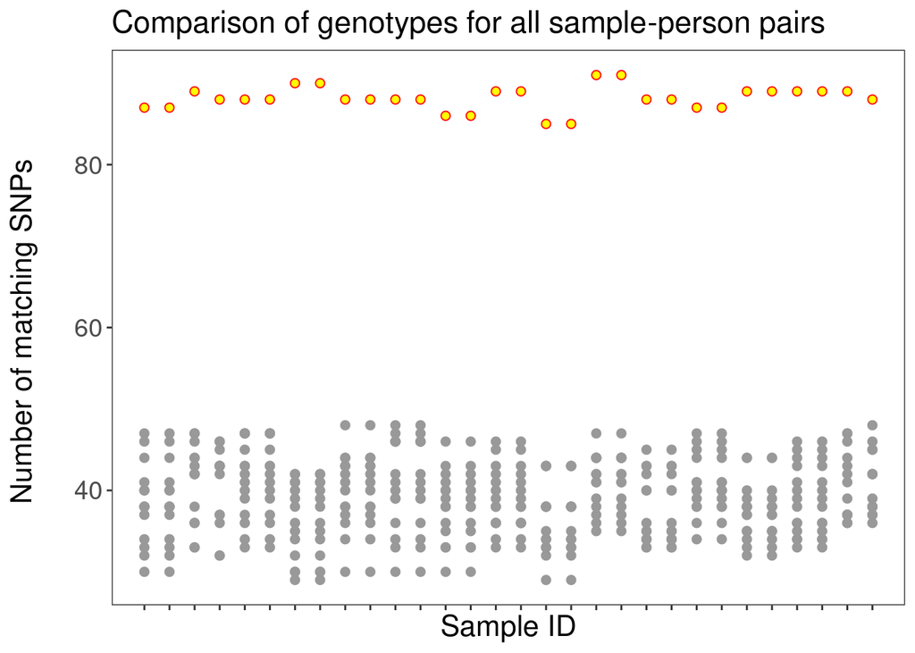

```r
out %>% ggplot(aes(x = sample_ID, y = n_snps)) +
  geom_point(fill = ifelse(out$actual_match == out$assumed_match,
                           'yellow', 'grey60'),
             color = ifelse(out$n_snps == out$max,
                            'red', 'grey60'),
             shape = 21, size = 2) +
  theme_bw() +
  ylab('Number of matching SNPs \n') + xlab('Sample ID') +
  ggtitle('Comparison of genotypes for all sample-person pairs') +
  theme(axis.text.x = element_text(angle = 90),
        panel.background = element_rect(fill = 'white'),
        axis.text.x.bottom = element_blank(),
        panel.grid = element_blank(),
        axis.title = element_text(size = 16),
        title = element_text(size = 14),
        axis.text.y = element_text(size = 14)) +
  scale_x_discrete(expand = c(-1.01,-1.01))
```

The smallest overlap is 85 SNPs and there are no mismatches.

```r
out %>% filter(n_snps == max) %>% arrange(max)
```

```
## # A tibble: 30 × 5
##    sample_ID           actual_match assumed_match n_snps   max
##    <chr>               <chr>        <chr>          <int> <int>
##  1 203548970025_R01C01 2272         2272              85    85
##  2 203548970025_R02C01 2272         2272              85    85
##  3 203548970014_R03C01 2214         2214              86    86
##  4 203548970014_R04C01 2214         2214              86    86
##  5 203527980075_R03C01 2185         2185              87    87
##  6 203527980075_R04C01 2185         2185              87    87
##  7 203548970062_R05C01 2188         2188              87    87
##  8 203548970062_R06C01 2188         2188              87    87
##  9 203527980082_R06C01 2168         2168              88    88
## 10 203548970102_R02C01 2251         2251              88    88
## # ℹ 20 more rows
```

```r
out %>% filter(n_snps == max) %>% filter(actual_match != assumed_match)
```

```
## # A tibble: 0 × 5
## # ℹ 5 variables: sample_ID <chr>, actual_match <chr>, assumed_match <chr>,
## #   n_snps <int>, max <int>
```

Save

```r
save(out, key_muscle, file='../GOTO_Data/Processing/Genotypes/GOTO_genotypeCheck-GOTO-muscle.Rdata')
```

## Fat

Create a data frame of assumed and actual matches for each sample

```r
dnam <- dnam_fat
gwas <- genotype_fat
key <- key_fat

out_fat <- data.frame()

for(j in 3:ncol(dnam)){
  ind <- dnam[,j]
for(i in 2:ncol(gwas)){
  out_fat <- rbind(out_fat,
  data.frame(sample_ID = (colnames(dnam)[j]),
  actual_match = colnames(gwas)[i],
  assumed_match = key[key$sample_ID == colnames(dnam)[j],'labnr'],
  n_snps = data.frame(xtabs(~gwas[,i] == ind))[2,2]))
}
}

out <- out_fat %>% group_by(sample_ID) %>% mutate(max = max(n_snps)) %>% ungroup()
```

We visualize the results. For every sample the assumed match also has the most matching SNPs, suggesting no sample mixups for fat

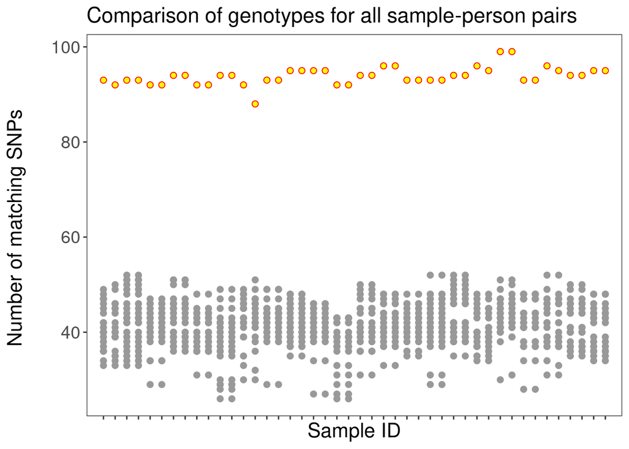

```r
out %>% ggplot(aes(x = sample_ID, y = n_snps)) +
  geom_point(fill = ifelse(out$actual_match == out$assumed_match,
                           'yellow', 'grey60'),
             color = ifelse(out$n_snps == out$max,
                            'red', 'grey60'),
             shape = 21, size = 2) +
  theme_bw() +
  ylab('Number of matching SNPs \n') + xlab('Sample ID') +
  ggtitle('Comparison of genotypes for all sample-person pairs') +
  theme(axis.text.x = element_text(angle = 90),
        panel.background = element_rect(fill = 'white'),
        axis.text.x.bottom = element_blank(),
        panel.grid = element_blank(),
        axis.title = element_text(size = 16),
        title = element_text(size = 14),
        axis.text.y = element_text(size = 14)) +
  scale_x_discrete(expand = c(-1.01,-1.01))
```

The smallest overlap is 88 SNPs and there are no mismatches.

```r
out %>% filter(n_snps == max) %>% arrange(max)
```

```
## # A tibble: 44 × 5
##    sample_ID           actual_match assumed_match n_snps   max
##    <chr>               <chr>        <chr>          <int> <int>
##  1 203548970042_R08C01 2141         2141              88    88
##  2 203527980024_R06C01 2272         2272              92    92
##  3 203548970042_R07C01 2141         2141              92    92
##  4 203548870042_R01C01 2185         2185              92    92
##  5 203548870042_R02C01 2185         2185              92    92
##  6 203548970029_R01C01 2202         2202              92    92
##  7 203548970029_R02C01 2202         2202              92    92
##  8 203548970079_R03C01 2261         2261              92    92
##  9 203548970079_R04C01 2261         2261              92    92
## 10 203527980024_R05C01 2272         2272              93    93
## # ℹ 34 more rows
```

```r
out %>% filter(n_snps == max) %>% filter(actual_match != assumed_match)
```

```
## # A tibble: 0 × 5
## # ℹ 5 variables: sample_ID <chr>, actual_match <chr>, assumed_match <chr>,
## #   n_snps <int>, max <int>
```

Save

```r
save(out, key_fat, file='../GOTO_Data/Processing/Genotypes/GOTO_genotypeCheck-GOTO-fat.Rdata')
```

Clear

```r
rm(list=ls())
```